# Social Network Analysis Home Assignment 2

# Graph models. Centrality metrics

## Task 1. Your social network

For the first task, you have to load your vk.com network. Please follow the instructions posted on the course wiki or user VK Application. For [FB](http://facebook.com) users try to use [NetVizz](http://thepoliticsofsystems.net/2010/03/netvizz-facebook-to-gephi/). If you did it correctly, you should have a GraphML file with your own network. Read it to R:

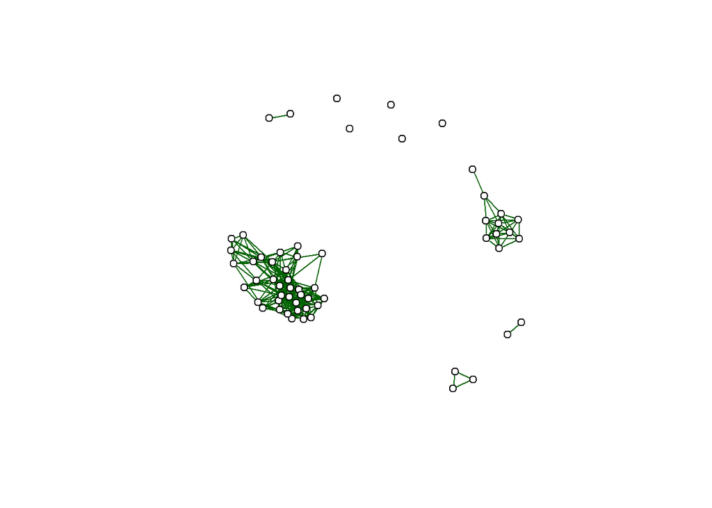

```r
gexf_vk_graph_path = file.path("C:", "Users", "Mikhail", "Desktop", "vk-friends-eng.gexf")
gexf_vk_graph = read.gexf(gexf_vk_graph_path)
vk_graph = gexf.to.igraph(gexf_vk_graph)

# rename vertices (remain only first names)
for (i in 1:length(V(vk_graph)$'name')) {
  V(vk_graph)[i]$'name' <- as.list(unlist(strsplit(V(vk_graph)[[i]]$'name', " ")))[1]
}

# Since there are two edges between friends (in and out),
# remain only one edge by converting directed graph to undirected
# it's optional
vk_graph <- as.undirected(vk_graph)
# There used to be 582 edges in the graph, now there are 291 edges

plot(vk_graph, vertex.label=NA, vertex.size=5, vertex.color="white", edge.color="darkgreen")
```

### 1. Degree distribution

First, plot degree distribution of your network in log-log scales:

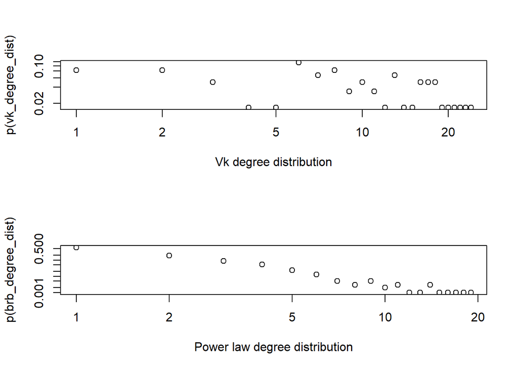

```r
# calculate degree distribution for vk graph
vk_degree_dist <- degree_distribution(vk_graph, cumulative=FALSE)

# create a graph that follows Power law
brb_graph <- barabasi.game(1000, directed=FALSE)
brb_degree_dist <- degree_distribution(brb_graph, cumulative=FALSE)

# plot both vk network distribution and power law network distribution
par(mfrow=c(2,1))
plot(vk_degree_dist[which(vk_degree_dist > 0)], log="xy", xlab="Vk degree distribution",
     ylab="p(vk_degree_dist)")
plot(brb_degree_dist[which(brb_degree_dist > 0)], log="xy", xlab="Power law degree distribution",
     ylab="p(brb_degree_dist)")
```

Is there any correspondence between actual degree distribution of your network and the Power Law distribution? If not, explain why.

It seems a bit like Power law. It will look more like Power law if there was more vertices in the Vk graph.

Now, let’s see how it would look if it was random. Produce Erdos-Renyi graph matching your real network (same number of nodes and same average degree). Compare it with your degree distribution.

```r
vk_graph_n_vertices <- length(V(vk_graph))
mean_vk_graph_degree <- mean(degree(vk_graph))
vk_edge_probability <- mean_vk_graph_degree / vk_graph_n_vertices

erdos_Renyi_graph <- erdos.renyi.game(vk_graph_n_vertices, vk_edge_probability)
erdos_Renyi_degree_dist <- degree_distribution(erdos_Renyi_graph, cumulative=FALSE)

mean(degree(vk_graph))
```

```
## [1] 9.7
```

```r
mean(degree(erdos_Renyi_graph))
```

```
## [1] 9.366667
```

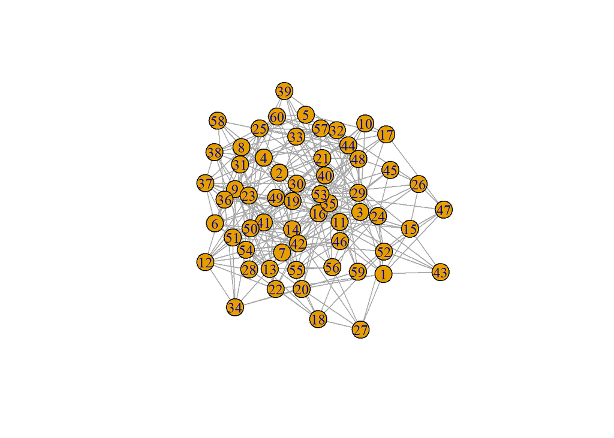

```r
plot(erdos_Renyi_graph)
```

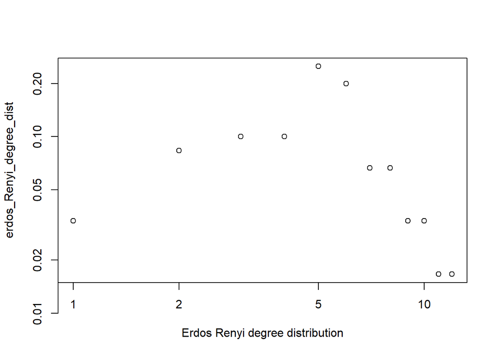

```r
plot(erdos_Renyi_degree_dist[which(erdos_Renyi_degree_dist > 0)], log="xy",
     xlab="Erdos Renyi degree distribution", ylab="erdos_Renyi_degree_dist")
```

```r
ks.test(vk_degree_dist, erdos_Renyi_degree_dist)
```

```
##
##  Two-sample Kolmogorov-Smirnov test
##
## data:  vk_degree_dist and erdos_Renyi_degree_dist
## D = 0.20487, p-value = 0.7593
## alternative hypothesis: two-sided
```

It’s not easy to see the difference with such small random graph, so let’s produce bigger one

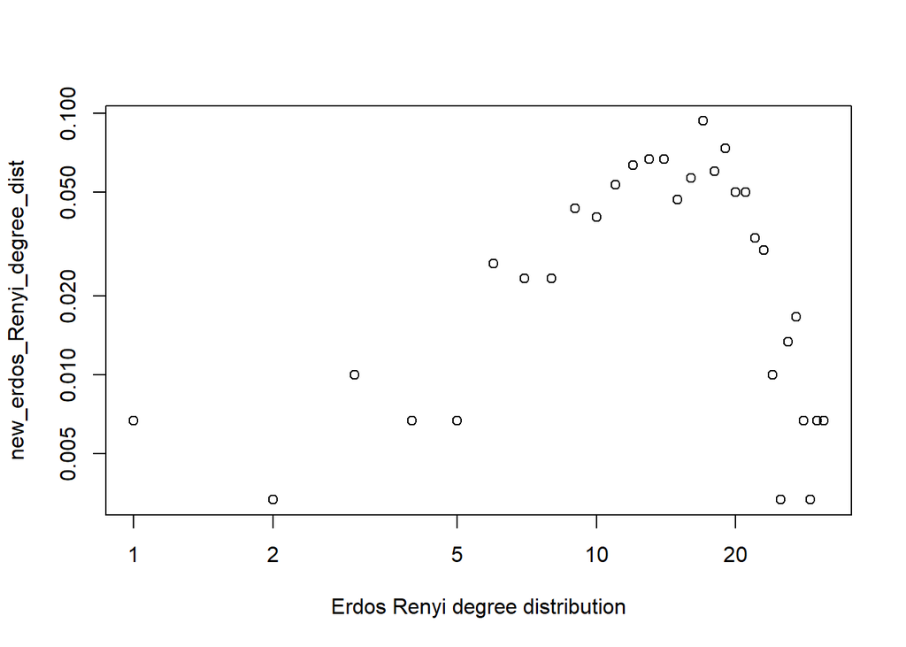

```r
new_erdos_Renyi_graph <- erdos.renyi.game(vk_graph_n_vertices * 5, vk_edge_probability)
new_erdos_Renyi_degree_dist <- degree_distribution(new_erdos_Renyi_graph, cumulative=FALSE)
plot(new_erdos_Renyi_degree_dist[which(new_erdos_Renyi_degree_dist > 0)], log="xy",
     xlab="Erdos Renyi degree distribution", ylab="new_erdos_Renyi_degree_dist")
```

```r
ks.test(vk_degree_dist, new_erdos_Renyi_degree_dist)
```

```
##
##  Two-sample Kolmogorov-Smirnov test
##
## data:  vk_degree_dist and new_erdos_Renyi_degree_dist
## D = 0.53971, p-value = 1.598e-05
## alternative hypothesis: two-sided
```

Now random graph follows normal distribution and the distributions of random graph and Vk graph are completely different.

### 2. Compute centrality metrics

Compute for your network:

- degree centrality
- closeness centrality
- betweenness centrality
- eigenvector centrality
- Bonacich power centrality
- Alpha centrality

```r
vk_degree <- degree(vk_graph)
vk_closeness <- closeness(vk_graph)
vk_betweenness <- betweenness(vk_graph)
vk_eigenvector <- evcent(vk_graph)$'vector'
vk_bonachich <- bonpow(vk_graph, rescale=TRUE, exponent=0.999) + 0.01
vk_alpha <- alpha.centrality(vk_graph, alpha=0.999) + 2

fine <- 500
palette <- colorRampPalette(c('blue','red'))
vk_degree_col <- palette(fine)[as.numeric(cut(vk_degree, breaks=fine))]
vk_closeness_col <- palette(fine)[as.numeric(cut(vk_closeness, breaks=fine))]
vk_betweenness_col <- palette(fine)[as.numeric(cut(vk_betweenness, breaks=fine))]
vk_eigenvector_col <- palette(fine)[as.numeric(cut(vk_eigenvector, breaks=fine))]
vk_bonachich_col <- palette(fine)[as.numeric(cut(vk_bonachich, breaks=fine))]
vk_alpha_col <- palette(fine)[as.numeric(cut(vk_alpha, breaks=fine))]
```

Output six plots corresponding to six centrality metrics you’ve computed:

- Use first names of your friends as node labels on the graph (you may hide this information if you wish – change it by integer ID)
- Keep the same layout of the network
- Make node sizes and colours proportional to the respective centrality metrics

Hint: If you get stuck, lab 4 script might be helpful.

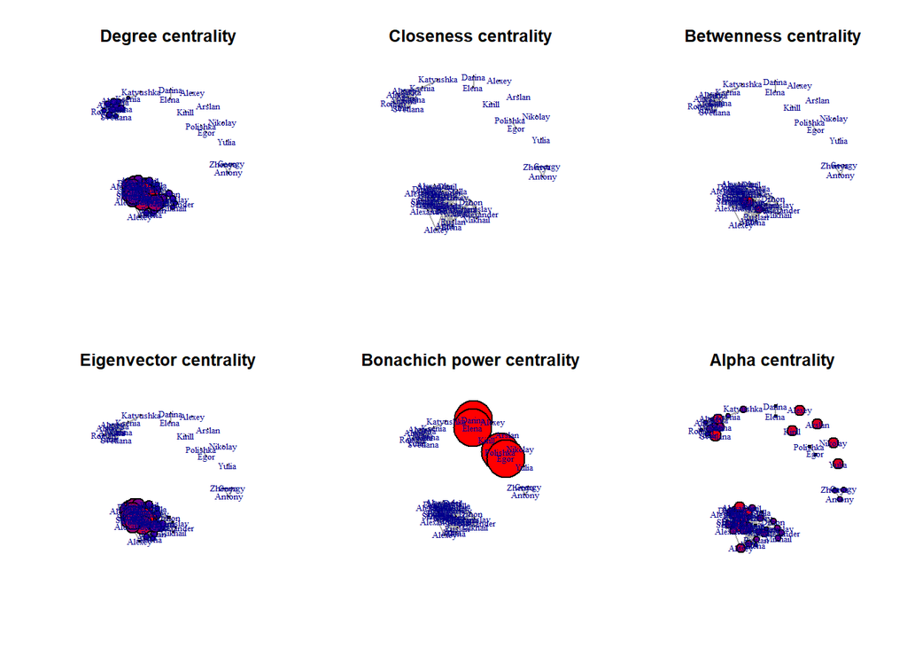

```r
# Plot 6 graphs in 2 rows and 3 columns
op <- par(mfrow = c(2, 3))
# Keep the same layout
lay <- layout.fruchterman.reingold(vk_graph)

plot(vk_graph, layout=lay, vertex.color=vk_degree_col, vertex.size=vk_degree * 1.5,
     vertex.label.cex=0.6, main="Degree centrality")
plot(vk_graph,layout=lay, vertex.color=vk_closeness_col, vertex.size=vk_closeness * 1500,
     vertex.label.cex=0.6, main="Closeness centrality")
plot(vk_graph,layout=lay, vertex.color=vk_betweenness_col, vertex.size=vk_betweenness * 0.2,
     vertex.label.cex=0.6, main="Betwenness centrality")
plot(vk_graph,layout=lay, vertex.size=vk_eigenvector * 40, vertex.color=vk_eigenvector_col,
     vertex.label.cex=0.6, main="Eigenvector centrality")
plot(vk_graph,layout=lay, vertex.size=vk_bonachich * 250, vertex.color=vk_bonachich_col,
     vertex.label.cex=0.6, main="Bonachich power centrality")
plot(vk_graph,layout=lay, vertex.size=vk_alpha * 5, vertex.color=vk_alpha_col,
     vertex.label.cex=0.6, main="Alpha centrality")
```

Now, output top ten nodes in each ranking. Again, print only first names in your table to keep privacy:

```r
sort(vk_degree, decreasing=TRUE)[1:10]
```

```
##   Pavel Mikhail    Oleg    Gleb  Dmitry  Polina  Andrey     Lev   Maria
##      28      27      23      21      20      19      18      18      18
##   Denis
##      17
```

```r
sort(vk_closeness, decreasing=TRUE)[1:10]
```

```
##        Pavel      Mikhail         Oleg         Gleb       Dmitry
## 0.0006811989 0.0006802721 0.0006765900 0.0006747638 0.0006738544
##        Maria        Denis     Viktoria       Andrey          Lev
## 0.0006720430 0.0006711409 0.0006711409 0.0006702413 0.0006702413
```

```r
sort(vk_betweenness, decreasing=TRUE)[1:10]
```

```
##  Mikhail    Maria    Pavel     Gleb   Dmitry     Oleg     Olya   Alexey
## 74.51918 63.03384 60.95564 30.67601 26.58498 24.20100 23.54902 18.77192
##    Denis   Oksana
## 17.82155 17.77648
```

```r
sort(vk_eigenvector, decreasing=TRUE)[1:10]
```

```
##     Pavel      Oleg   Mikhail    Polina    Dmitry      Gleb    Andrey
## 1.0000000 0.9154841 0.8752949 0.7883346 0.7657927 0.7597537 0.7466906
##  Viktoria     Pavel      Anya
## 0.7301830 0.7186315 0.7165267
```

```r
sort(vk_bonachich, decreasing=TRUE)[1:10]
```

```
##     Darina   Polishka      Elena       Egor      Elena     Sergey
## 0.26301741 0.26301741 0.26301741 0.26301741 0.01123694 0.01107645
##     Alexey      Elena      Danil     Zhorzh
## 0.01084942 0.01060472 0.01052770 0.01049544
```

```r
sort(vk_alpha, decreasing=TRUE)[1:10]
```

```
##  Svetlana  Viktoria    Nikita Alexander Alexander   Nikolay    Arslan
##  3.376458  3.175459  3.113442  3.041683  3.031725  3.000000  3.000000
##    Kirill    Alexey     Yulia
##  3.000000  3.000000  3.000000
```

Eigenvector centrality looks almost the same as degree centrality. People with highest closeness centrality have a lot of mutual friends (this list is very similar to degree centrality top10 list). People with high betweenness centrality have a lot of friend (are kinda hubs). There is nothing unexpected in these plots.

## Task 2. Flickr network

In the second task, you will work with a large directed graph.

Please download flickr.mat

*Data contains sparse matrix A and list of user names. This is a denser part of the Flickr photo sharing site friendship graph from 2006. Edge direction corresponds to friendship requests (following). Some of the links are reciprocal, others not*

It’s a Matlab file. How to deal with it in R? There is a package `R.matlab`. Please install it and call `library(R.matlab)`

Now use `readMat` function to read the file and extract adjacency matrix and a list of user names:

```r
flickr_path <- file.path("C:", "Users", "Mikhail", "Desktop", "SNA2", "flickr.mat")
flickr = readMat(flickr_path)
fmatrix=as.matrix(flickr[1]$A)
fnames=flickr[2]$names
```

If you have trouble loading large mat file on your laptop — try to use HSE computer classes with installed R+RStudio.

Look at user names. You might want to remove spaces from the names. Use a function `gsub` to remove them:

```r
fnames=gsub(" ", "", fnames)
```

Now create a graph, output the number of vertices and edges:

```r
flickr_graph <- graph_from_adjacency_matrix(fmatrix)
vcount(flickr_graph)
```

```
## [1] 15724
```

```r
ecount(flickr_graph)
```

```
## [1] 510983
```

Compute in- and out- degree centralities, PageRank, Hubs and Authorities for this network:

```r
in_degree_flickr <- degree(flickr_graph, mode="in")
out_degree_flickr <- degree(flickr_graph, mode="out")
pr_flickr <- page_rank(flickr_graph)$'vector'
hub_flicker <- hub_score(flickr_graph)$'vector'
authority_flicker <- authority_score(flickr_graph)$'vector'
```

Print top ten names in each ranking:

```r
fnames[order(in_degree_flickr, decreasing=TRUE)[1:10]]
```

```
##  [1] "awfulsara"        "drp"              "*Ivan*"
##  [4] "antimethod"       "DrJoanne"         "BombDog"
##  [7] "SimonPais"        "deborahlattimore" "MaDGi®L•\231"
## [10] "notraces"
```

```r
fnames[order(out_degree_flickr, decreasing=TRUE)[1:10]]
```

```
##  [1] "anildash"      "tozzer"        "AtiRanA"       "pixietart"
##  [5] "jakedobkin"    "Buntekuh"      "brainware3000" "Jakes_World"
##  [9] "maximolly"     "AndreiaLopes"
```

```r
fnames[order(pr_flickr, decreasing=TRUE)[1:10]]
```

```
##  [1] "awfulsara"        "drp"              "antimethod"
##  [4] "BombDog"          "*Ivan*"           "DrJoanne"
##  [7] "MaDGi®L•\231"        "SimonPais"        "deborahlattimore"
## [10] "cymagen"
```

```r
fnames[order(hub_flicker, decreasing=TRUE)[1:10]]
```

```
##  [1] "mrpiink"     "automat"     "schizoo23"   "lorrainemd"  "sgoralnick"
##  [6] "*starlet*"   "brynfoto"    "liquidpixel" "noahstone"   "isherwood"
```

```r
fnames[order(authority_flicker, decreasing=TRUE)[1:10]]
```

```
##  [1] "awfulsara"        "drp"              "DrJoanne"
##  [4] "*Ivan*"           "antimethod"       "BombDog"
##  [7] "SimonPais"        "deborahlattimore" "cymagen"
## [10] ":Nikola"
```

Produce the following plots:

- In-degree centralities versus out-degree centralities
- In-degree centralities versus authorities
- Out-degree centralities versus hubs
- Hubs versus authorities
- PageRank versus hubs
- PageRank versus authorities

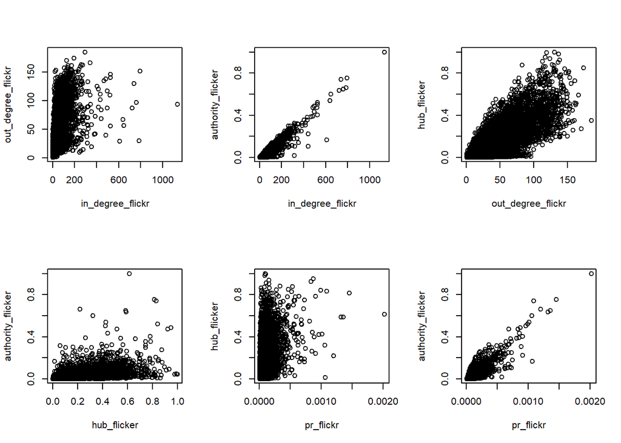

```r
op <- par(mfrow = c(2, 3))
plot(in_degree_flickr, out_degree_flickr)
plot(in_degree_flickr, authority_flicker)
plot(out_degree_flickr, hub_flicker)
plot(hub_flicker, authority_flicker)
plot(pr_flickr, hub_flicker)
plot(pr_flickr, authority_flicker)
```